# Car Acceptability Category Prediction Analysis

Author

Jiaming Change, Yicheng Huang, Effie Wang, & Brianna Zhou

## Summary

We aim to develop a Random Forest classification model to predict car acceptability categories: unacceptable (unacc), acceptable (acc), good (good), and very good (vgood). This prediction is based on categorical attributes such as price, maintenance cost, safety, and seating capacity. The data is sourced from the Car Evaluation dataset found in the UCI Machine Learning Repository (Bohanec 1988).

In summary, this analysis demonstrates how machine learning can be effectively applied to real-world decision-making in the automotive sector.

## Introduction

Evaluating car acceptability is a critical factor in decision-making within the automotive industry. It affects consumer choices regarding vehicle purchases, manufacturers’ priorities, and dealership strategies. Car purchases represent one of the most significant financial decisions for households, with affordability being the primary barrier for many buyers. Price plays a crucial role in accessibility, particularly for budget-conscious consumers, such as first-time buyers or individuals in emerging markets.

According to Chiu, Du, and Wang (2022), price dispersion positively impacts car acceptability. Because car purchases are high-cost, long-term investments, misaligned choices due to information asymmetry—such as undervaluing safety features—can lead to serious financial or safety repercussions (Financial Consumer Agency of Canada 2024). For instance, vehicles with poor safety ratings have been linked to higher accident rates. Consequently, Vrkljan and Anaby (2011) concluded that safety is considered the most important feature when purchasing a vehicle. Automating car evaluations helps buyers efficiently identify optimal vehicles, aligning with the trend toward data-driven consumer tools. Recognizing critical features, such as safety and price, reflects the industry’s priorities in vehicle design.

This project aims to develop a classification model to predict car acceptability based on various features such as price, maintenance cost, safety, and seating capacity. This analysis uses the [Car Evaluation dataset](https://archive.ics.uci.edu/dataset/19/car+evaluation), which contains 1,728 instances and six features: buying price, maintenance cost, number of doors, seating capacity, luggage size, and safety rating. With an increasing number of car models available in the market, understanding how different attributes affect car classification can help streamline the evaluation process. The goal is to predict car acceptability categories: unacceptable (unacc), acceptable (acc), good (good), and very good (vgood). Being able to predict car acceptability can enhance automated recommendations, improve quality control, and support consumer purchasing decisions.

## Method & Results

### Importing Data & Data Exploration

Reads the dataset, assigns appropriate and meaningful column names, checks the number of rows, and convert all categorical variables into factors. The dataset consists of 1,728 rows with 6 categorical features related to car evaluation.

Table 1: Cleaned Data

| buying | maint | doors | persons | lug_boot | safety | class |
| --- | --- | --- | --- | --- | --- | --- |
| vhigh | vhigh | 2 | 2 | small | low | unacc |
| vhigh | vhigh | 2 | 2 | small | med | unacc |
| vhigh | vhigh | 2 | 2 | small | high | unacc |
| vhigh | vhigh | 2 | 2 | med | low | unacc |
| vhigh | vhigh | 2 | 2 | med | med | unacc |

### Summary and Missing Data Check

Provides a summary of each feature, including frequency distributions and potential missing values. It also checks for class imbalance in the target variable `class`. There is no missing value in attributes.

```
   buying      maint       doors     persons     lug_boot    safety
 high :432   high :432   2    :432   2   :576   big  :576   high:576
 low  :432   low  :432   3    :432   4   :576   med  :576   low :576
 med  :432   med  :432   4    :432   more:576   small:576   med :576
 vhigh:432   vhigh:432   5more:432
   class
 acc  : 384
 good :  69
 unacc:1210
 vgood:  65
```

### Class Distribution Visualization

Generates a bar chart showing how the car evaluations are distributed across different categories. This helps identify class imbalances.

Table 2: Frequency distribution of the Car Acceptability Category.

| class | Frequency |
| --- | --- |
| acc | 384 |
| good | 69 |
| unacc | 1210 |
| vgood | 65 |

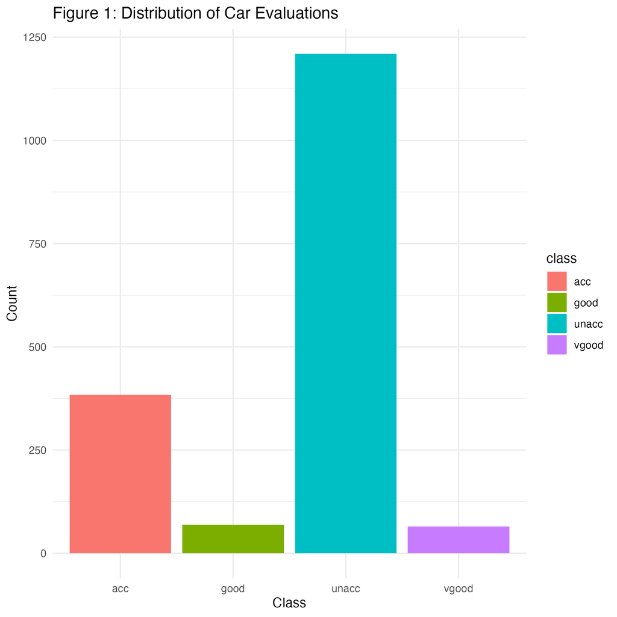

Figure 1: Distribution of Car Evaluations

### Feature Relationships Visualization

Creates bar charts for each feature to analyze its relationship with the target variable `class`. This helps identify important factors influencing car evaluations.

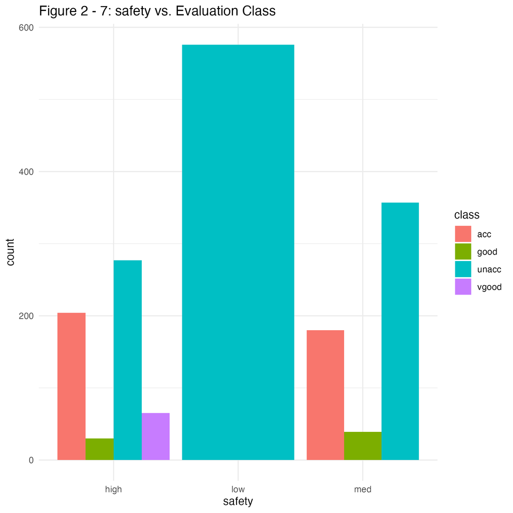

Figure 2: Safety vs. Evaluation Class

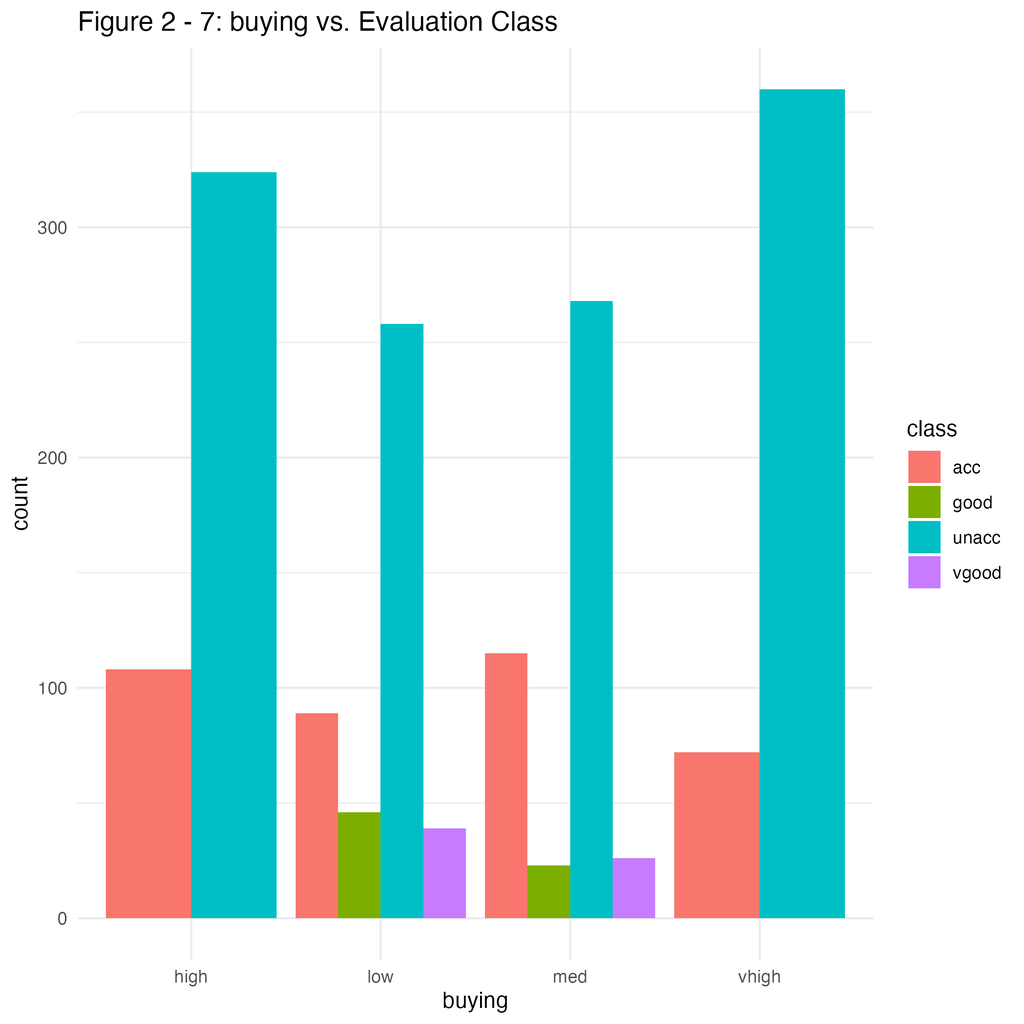

Figure 3: Buying vs. Evaluation Class

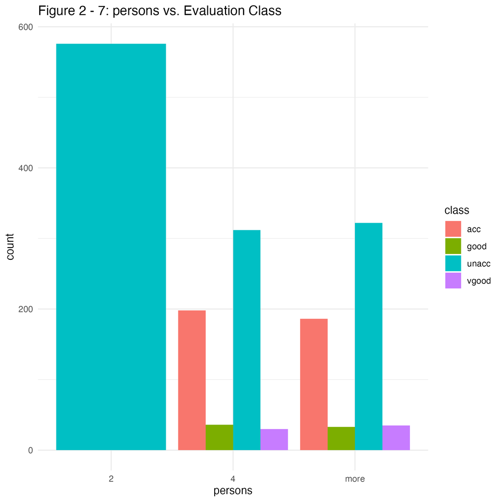

Figure 4: Number of Passenger vs. Evaluation Class

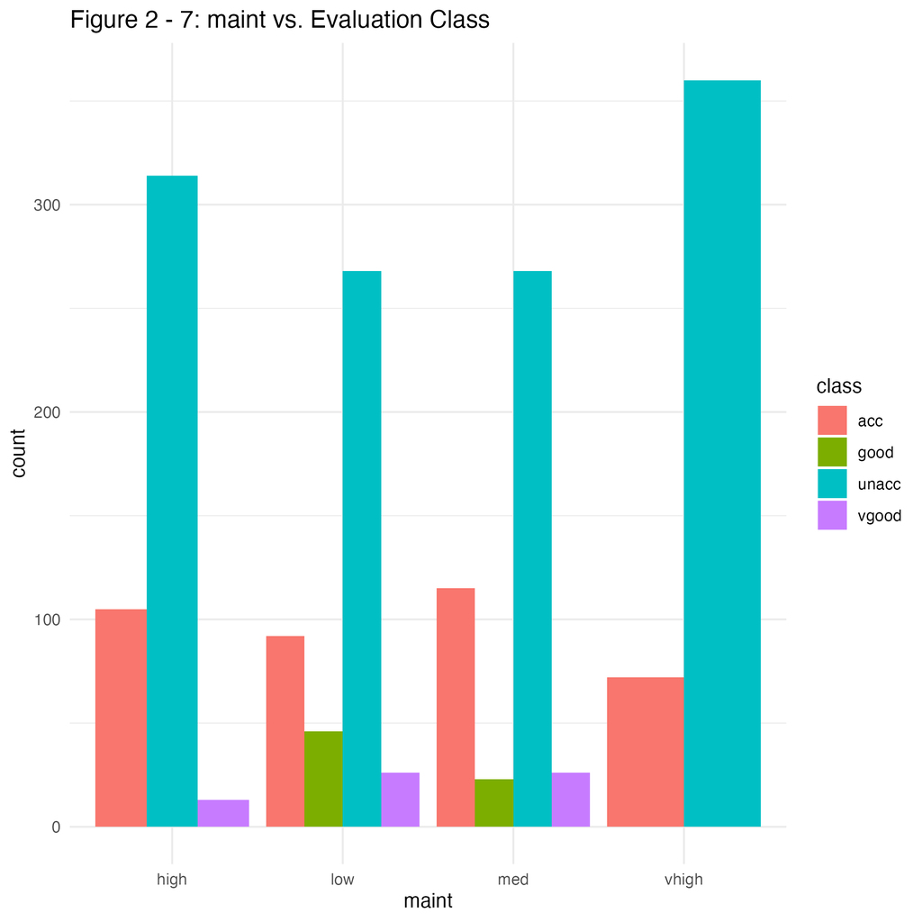

Figure 5: Maintenance vs. Evaluation Class

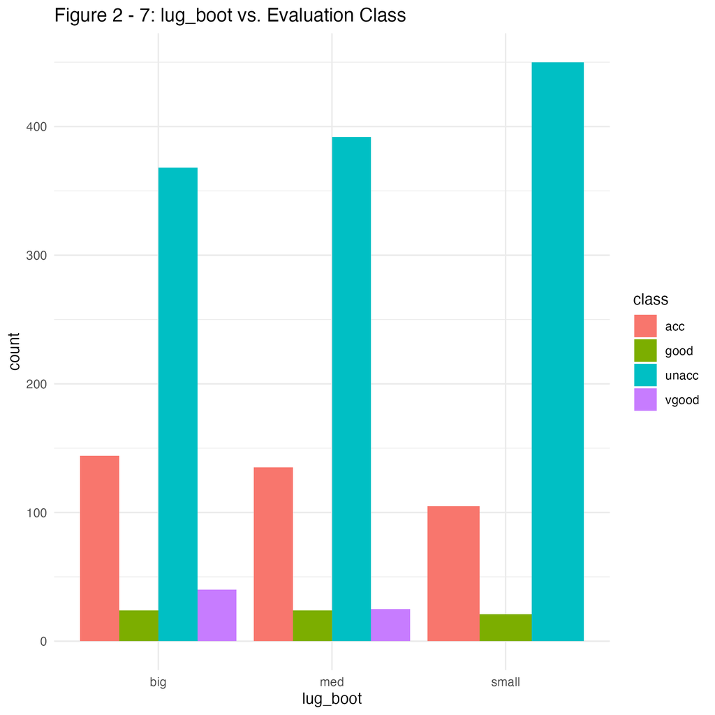

Figure 6: Luggage Boot Size vs. Evaluation Class

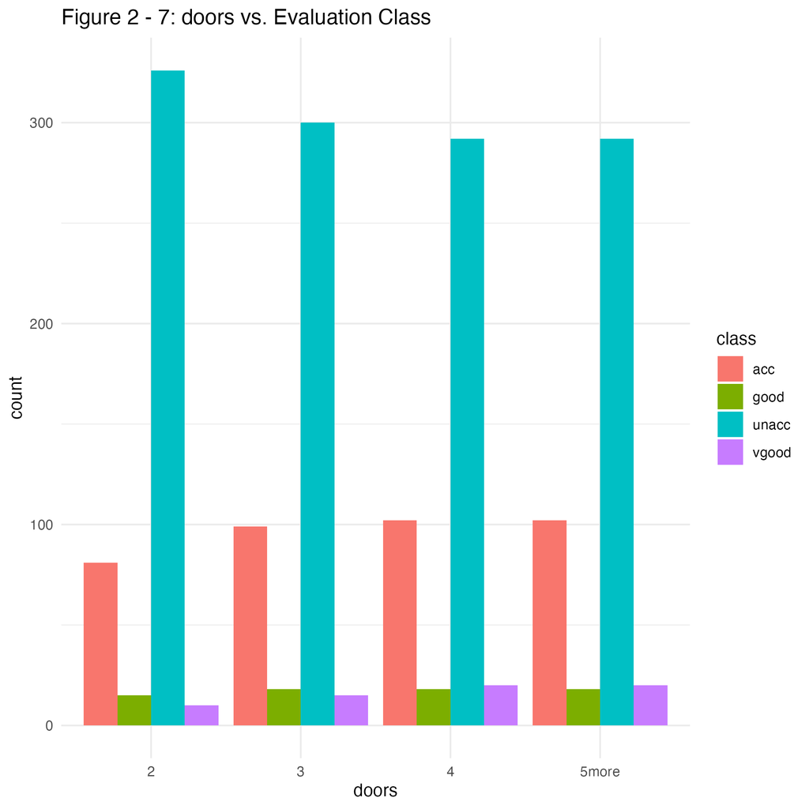

Figure 7: Number of Doors vs. Evaluation Class

The analysis of various features—such as safety Figure 2, buying price Figure 3, passenger capacity Figure 4, maintenance cost Figure 5, luggage boot size Figure 6, and number of doors—shows Figure 7 that the dominant classification is `unacc` (unacceptable), which indicates a pattern of negative evaluations.

The number of doors appears to have a minimal impact on the evaluations, as `unacc` remains the most common classification regardless of this feature.

### Feature Engineering and Data Resampling

Table 3: Ordinal Encoding of Categorical Variables.

| buying | maint | doors | persons | lug_boot | safety | class |
| --- | --- | --- | --- | --- | --- | --- |
| 4 | 4 | 2 | 2 | 3 | 2 | 3 |
| 4 | 4 | 2 | 2 | 3 | 3 | 3 |
| 4 | 4 | 2 | 2 | 3 | 1 | 3 |
| 4 | 4 | 2 | 2 | 2 | 2 | 3 |
| 4 | 4 | 2 | 2 | 2 | 3 | 3 |

### Handling Class Imbalance Using SMOTE

There is a great imbalance across different classes, introducing SMOTE (Synthetic Minority Over-sampling Technique) to generate synthetic samples in order, balance the dataset, reducing bias in classification, which improves the distribution.

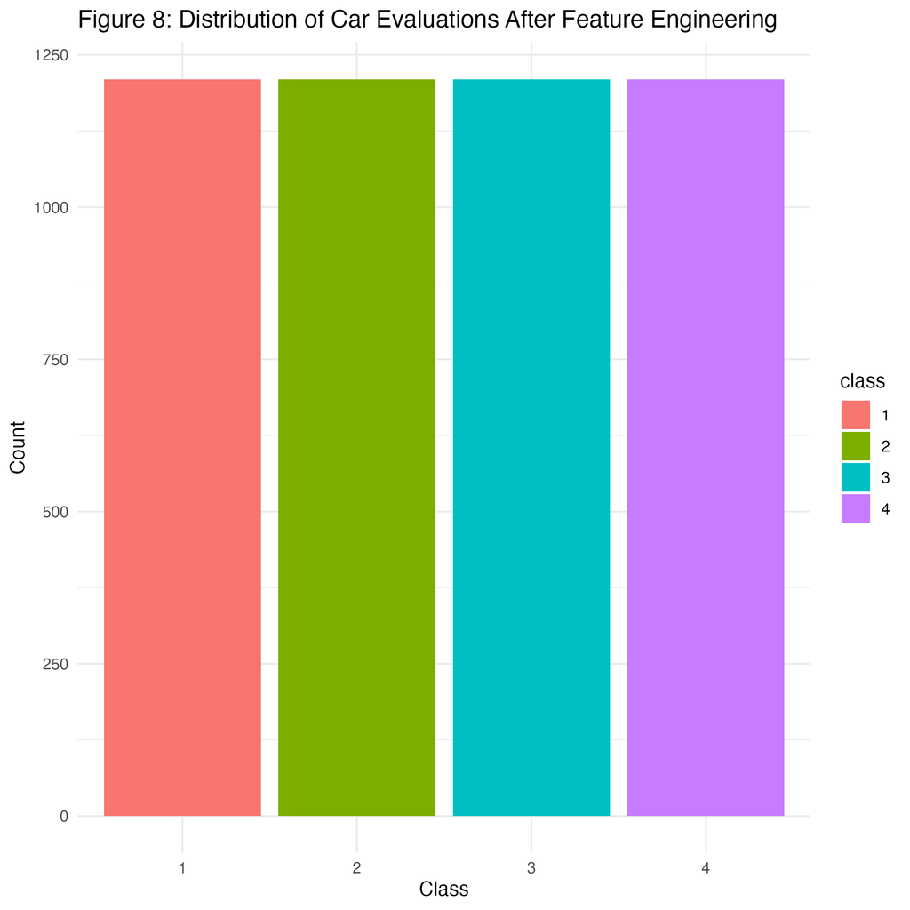

Figure 8: Distribution of Car Evaluations After Feature Engineering

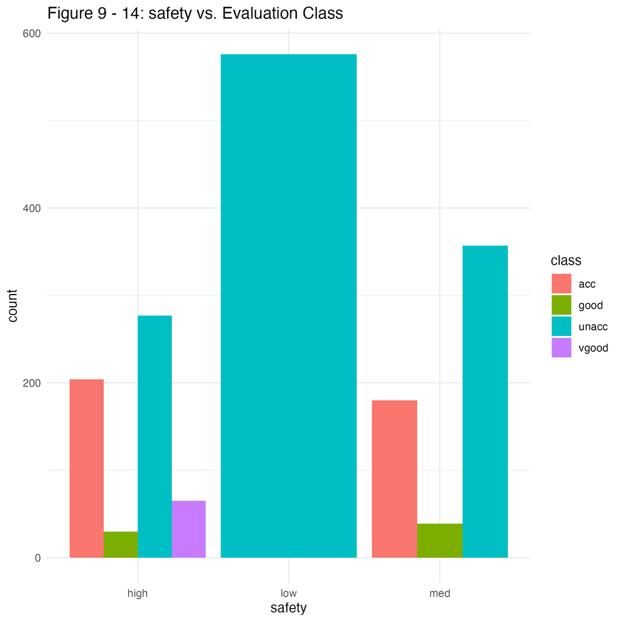

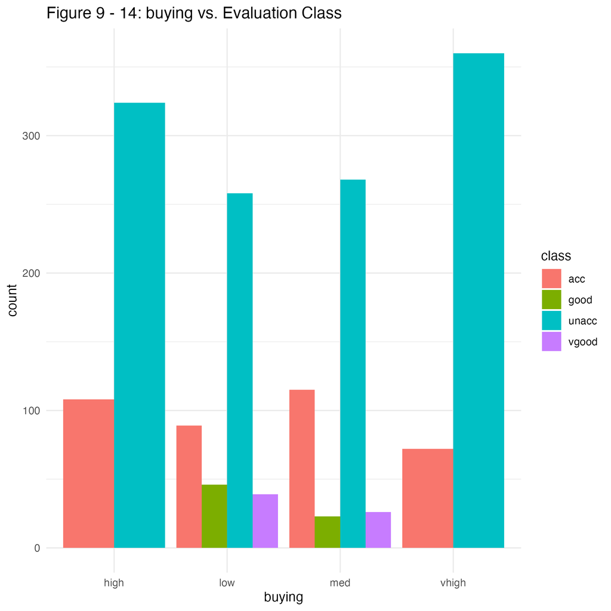

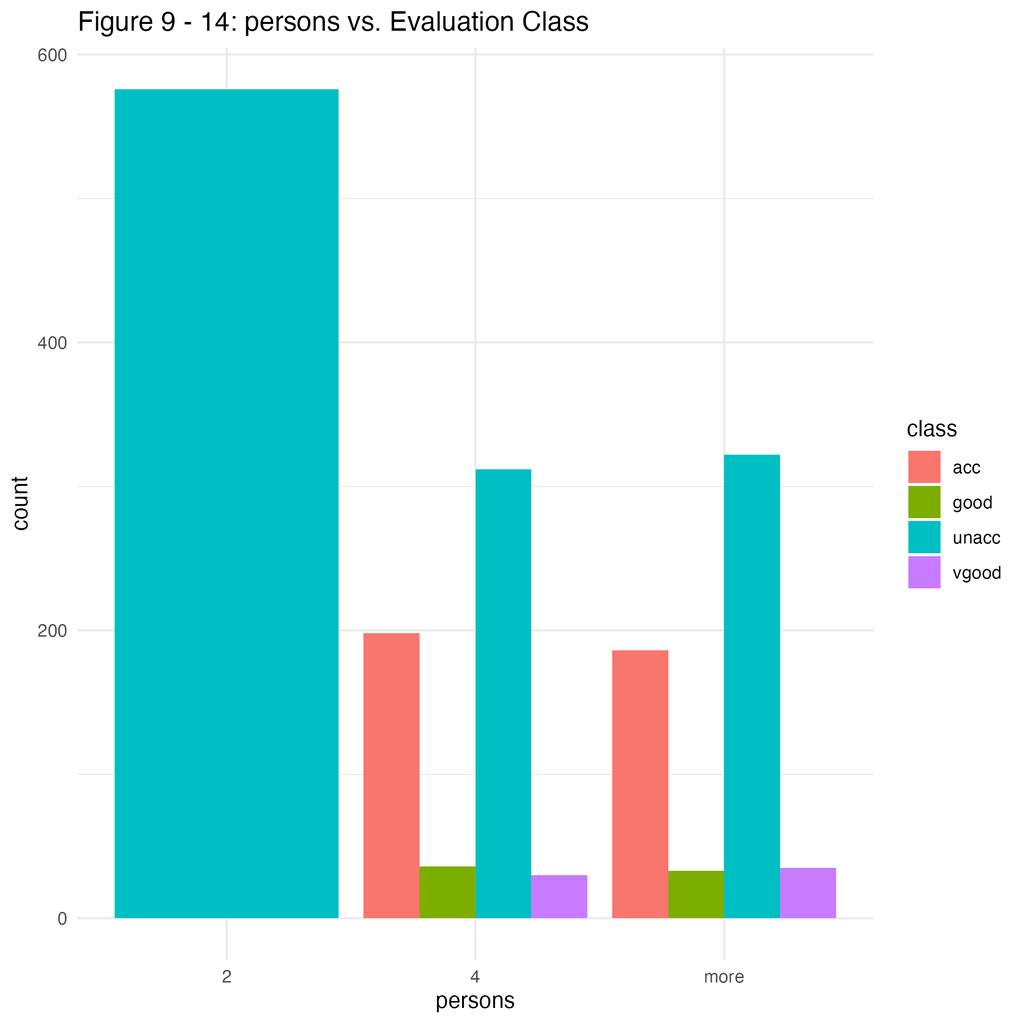

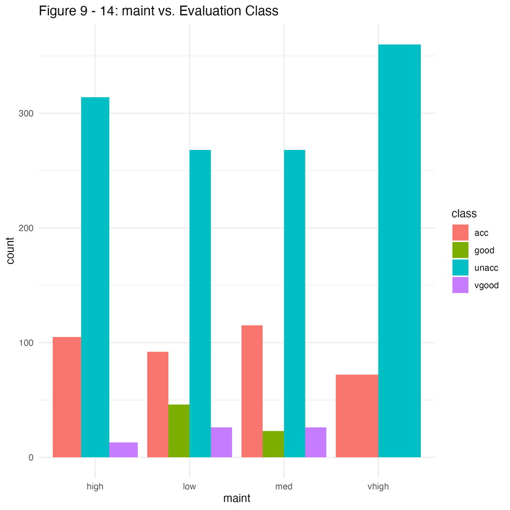

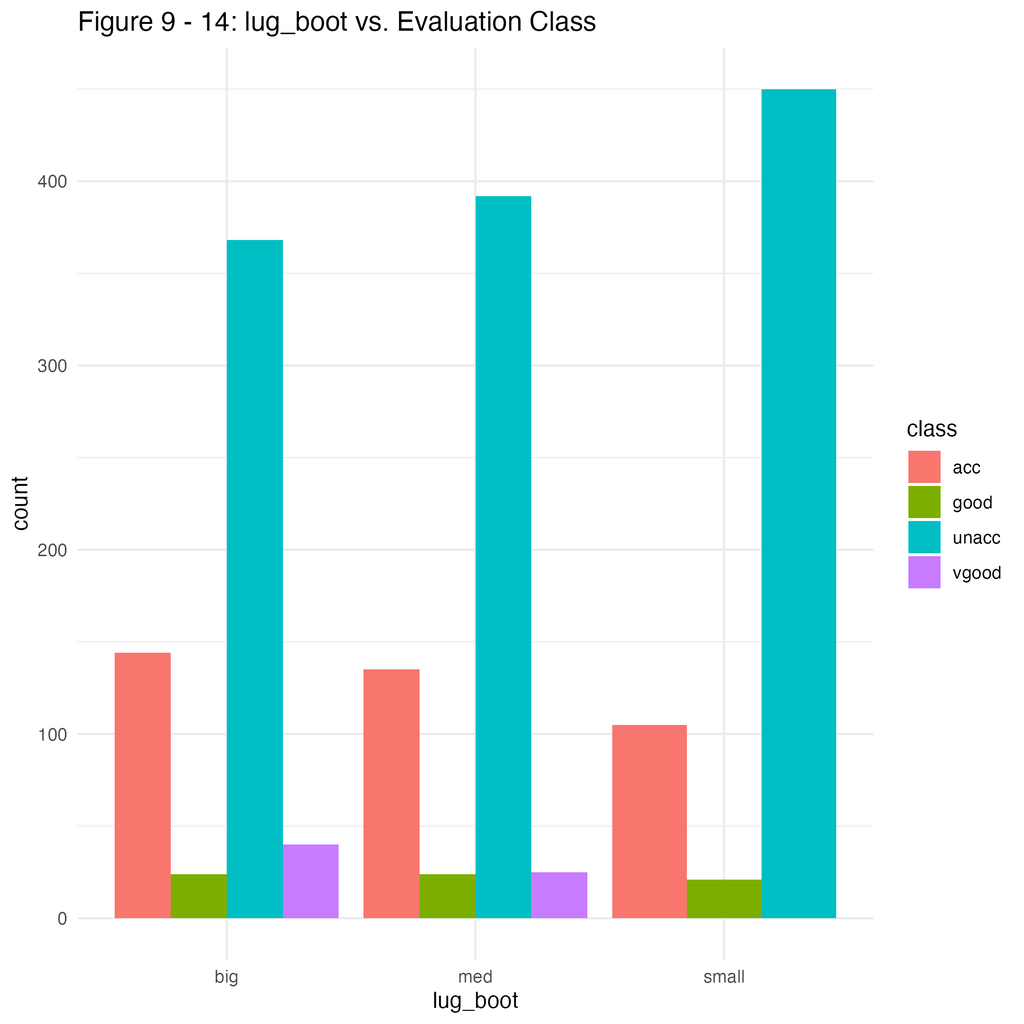

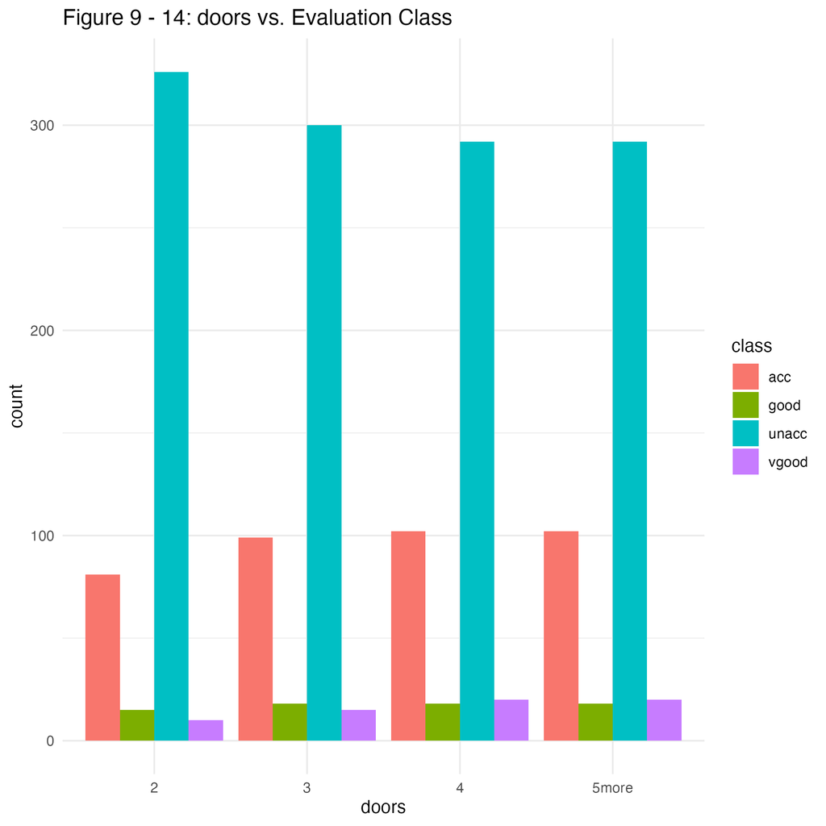

### Correlation Heatmap

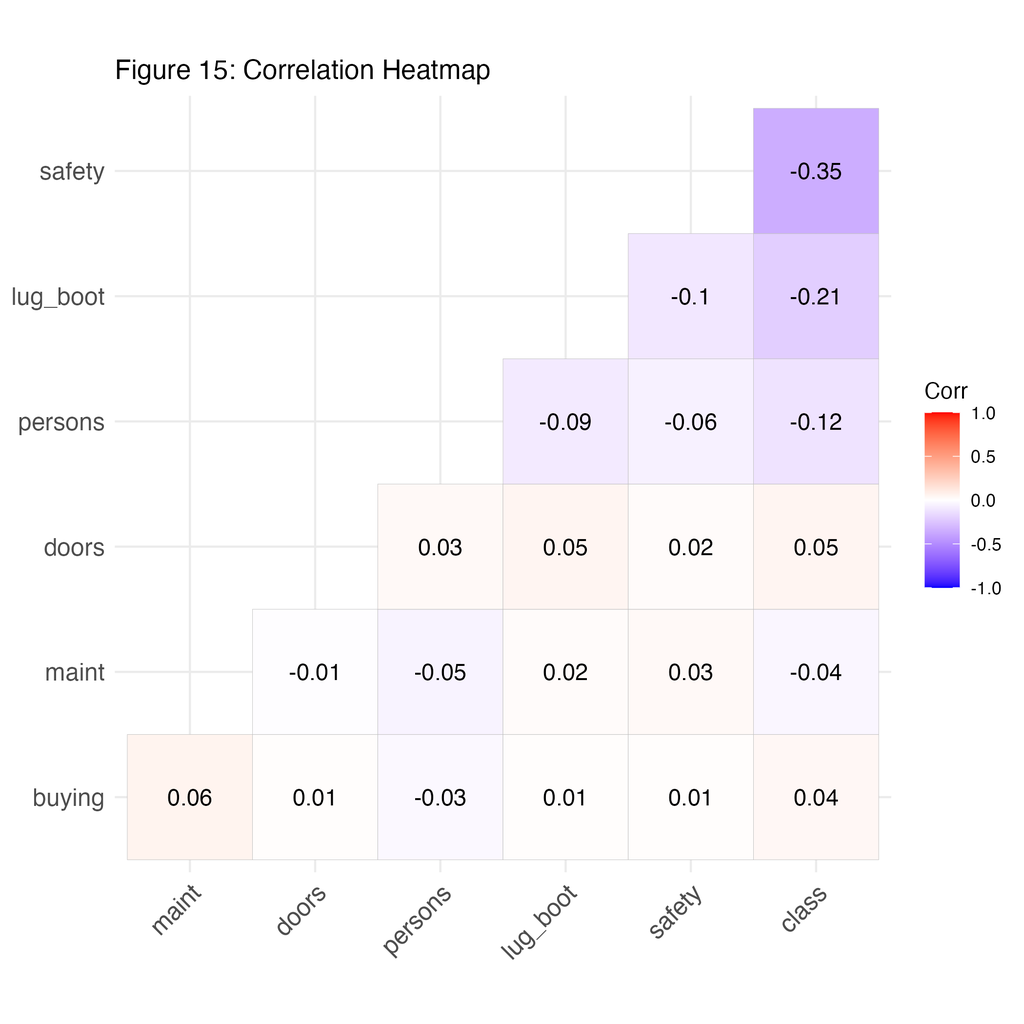

Figure 15: Correlation Heatmap

Generates a correlation heatmap to examine relationships between features. Helps identify redundant or highly correlated features. This visualization Figure 15 illustrates the correlation and feature importance of various factors that influence car evaluation outcomes. The values range from -1, indicating a strong negative association, to +1, which indicates a strong positive association.

### Classification Model

Table 4: Confusion Matrix of Random Forest Model

|  | x |
| --- | --- |
| Accuracy | 0.9876033 |
| Kappa | 0.9834522 |
| AccuracyLower | 0.9796359 |
| AccuracyUpper | 0.9930455 |
| AccuracyNull | 0.2801653 |
| AccuracyPValue | 0.0000000 |
| McnemarPValue | NaN |

|  | Sensitivity | Specificity | Pos Pred Value | Neg Pred Value | Precision | Recall | F1 | Prevalence | Detection Rate | Detection Prevalence | Balanced Accuracy |
| --- | --- | --- | --- | --- | --- | --- | --- | --- | --- | --- | --- |
| Class: 1 | 0.9897959 | 0.9901747 | 0.9700000 | 0.9967033 | 0.9700000 | 0.9897959 | 0.9797980 | 0.2429752 | 0.2404959 | 0.2479339 | 0.9899853 |
| Class: 2 | 1.0000000 | 0.9935275 | 0.9792388 | 1.0000000 | 0.9792388 | 1.0000000 | 0.9895105 | 0.2338843 | 0.2338843 | 0.2388430 | 0.9967638 |
| Class: 3 | 0.9646018 | 1.0000000 | 1.0000000 | 0.9864100 | 1.0000000 | 0.9646018 | 0.9819820 | 0.2801653 | 0.2702479 | 0.2702479 | 0.9823009 |
| Class: 4 | 1.0000000 | 1.0000000 | 1.0000000 | 1.0000000 | 1.0000000 | 1.0000000 | 1.0000000 | 0.2429752 | 0.2429752 | 0.2429752 | 1.0000000 |

The model achieved an overall accuracy approximately of 0.988, correctly classifying cars in most cases. The approximate Kappa score 0.983 indicates a strong agreement between predictions and actual labels, while the high sensitivity and specificity values demonstrate excellent detection ability across all classes.

### Result Visualization

We visualize the confusion matrix to get a better idea of the accuracy of the model.

Table 5: Confusion Matrix of Random Forest Model

| 1 | 2 | 3 | 4 |
| --- | --- | --- | --- |
| 291 | 0 | 9 | 0 |
| 3 | 283 | 3 | 0 |
| 0 | 0 | 327 | 0 |
| 0 | 0 | 0 | 294 |

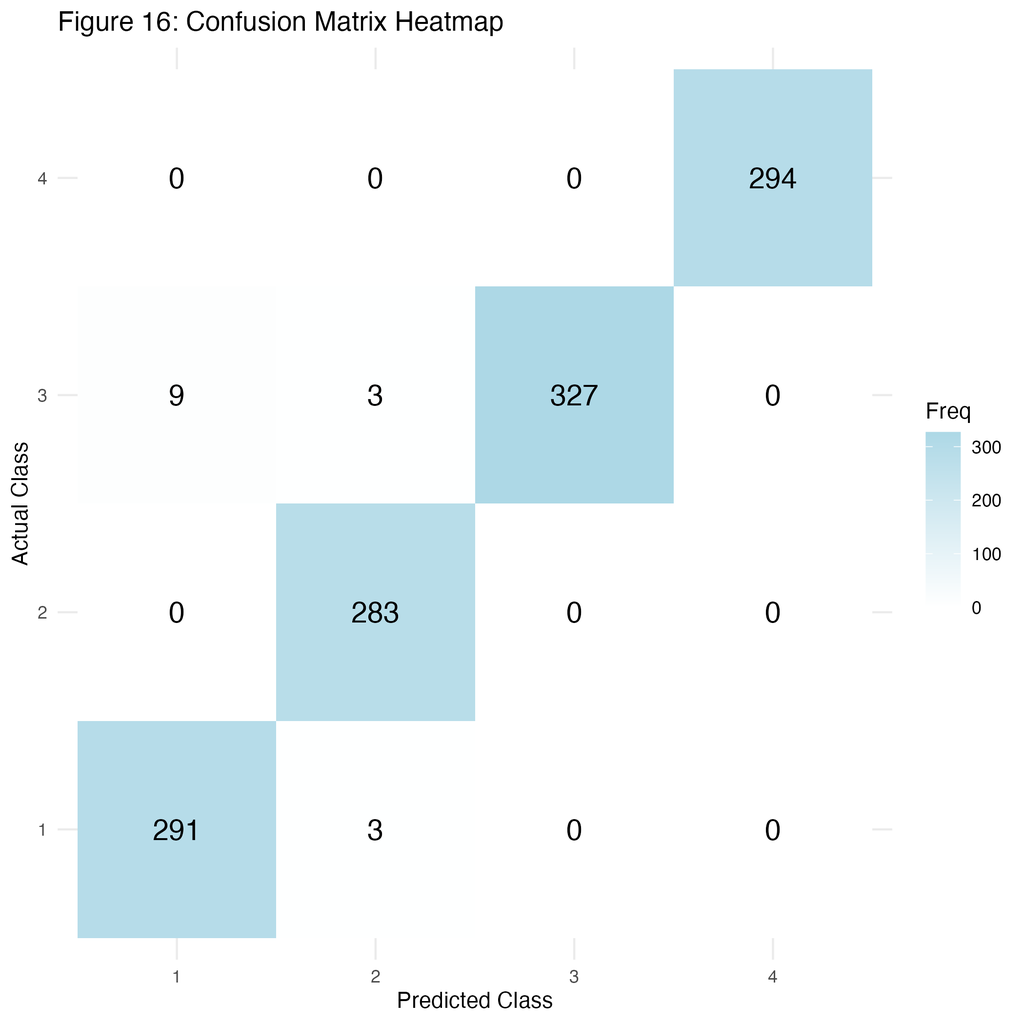

Figure 16: Confusion Matrix Heatmap

In Figure 16 and Table 5, the diagonal elements represent correct classifications, which means the model accurately predicted those classes of car. The off-diagonal elements represent incorrect classifications, which shows errors in the model made. Most of the predictions fall on the diagonal line, suggesting that the model performs very well in predicting the dataset. There are few cases of misclassification, which means that the accuracy rate is high.

## Discussion

Our random forest model achieves approximate accuracy of 98.8% and a strong Kappa statistic about 0.983, which shows it effectively predicts car acceptability base on the six measurements.

The results we got were very much in line with our expectations as our model performed very well. Our model correctly classifies almost all cars into the correct acceptable categories.

The results we get are very important for decision-making in the automotive industry. Consumers can choose to purchase vehicles based on demand, manufacturers can prioritize the demand for vehicle production, and dealers can develop strategies that are more in line with the market.

Our model is very good, but we still have some interesting questions for the future. Will additional features, such as brand, have an impact on the prediction? Is there any other model that is faster with no loss of accuracy? How is it possible to make our model more realistic? In conclusion, in the future, we may refine the data, compare more models, or try to apply our models to real-world problems.

## References

Bohanec, Marko. 1988. “Car Evaluation [Dataset].” *UCI Machine Learning Repository*. https://doi.org/10.24432/C5JP48.

Chiu, L., J. Du, and N. Wang. 2022. “The Effects of Price Dispersion on Sales in the Automobile Industry: A Dynamic Panel Analysis.” *SAGE Open*. https://doi.org/10.1177/21582440221120647.

Financial Consumer Agency of Canada. 2024. “Government of Canada.” https://www.canada.ca/en/financial-consumer-agency/services/loans/financing-car/risks.html.

Vrkljan, Brenda H., and Dana Anaby. 2011. “What Vehicle Features Are Considered Important When Buying an Automobile? An Examination of Driver Preferences by Age and Gender.” *Journal of Safety Research* 42 (1): 61–65. https://doi.org/10.1016/j.jsr.2010.11.006.